# RAMP Model Library

`dev`

$\otimes$ | hub | map | active

## Vignettes

- `exDE` for mathematicians (with Juliet and Doreen).

## Software

### $\oplus$

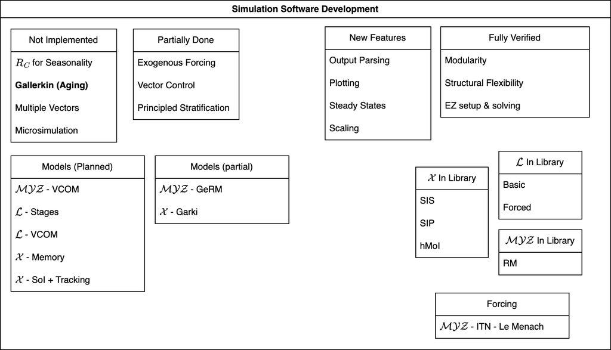

The software design phase is finally done, so development is no longer an open-ended task. It is now possible to delimit a finite set of tasks that would make the software fully functional. Most of these tasks have been started and there are links to documents in some stage of fulfillment.

- **exDE - Software Development Tasks**
- **MicroMoB - Software Development**
- **Model Library Development**
- **Robust Progressive Estimation**

### `exDE`

**high priority**

- The functions that implement specific kinds of **exogenous forcing** need to be finalized (see the list in **Figure 1**).
- Add the functions that compute temporal reproductive numbers.
- We need to add examples of parameter modification by exogenous variables describing weather, hydrology, and vector control modifying parameters. For example, $f=F_f(t, \ldots)$. Examplars need to be integrated into `exDE` mainly through examples:
  - The $\cal MY$ workhorse here is `GeRM`.
  - The $\cal L$ workhorse here is `LBasic`
- The library of models needs to be expanded (see below)
- `exDE` needs to be extended to handle multiple vector species. At the present time, `MYZpar` and `Lpar` are simple lists describing a single species `dMMYZdt` and `dLdt` are designed to compute the derivatives for variables describing a single species. To extend `exDE` for `nSpecies > 1`, many functions in `xDE_diffeqn` would need to be modified. This is a non-trivial upgrade.

**lower priority**

- Most exogenous forcing variables can be *computed* by calling a trace function. This does not handle every case. The current version of `exDE` does not accommodate computation of any **exogenous factor** as an **endogenous variable**. One example would be simulating hydrology and water levels for aquatic habitat dynamics in response to rainfall.

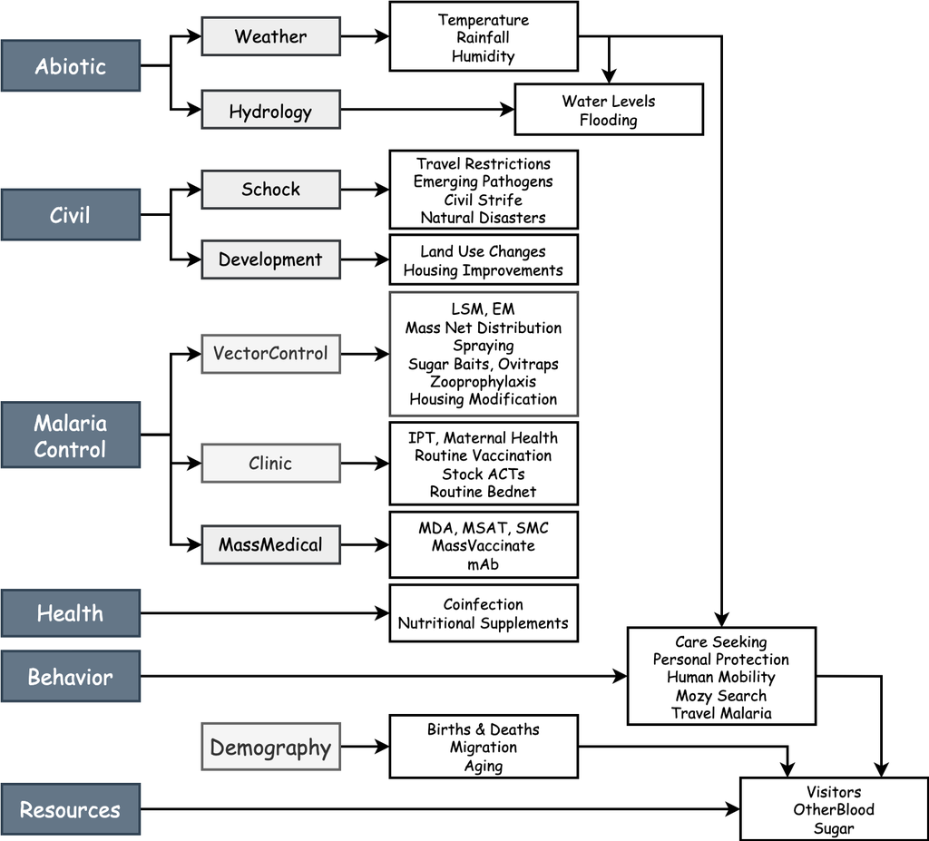

**Figure 1**

### MicroMoB

- The functionality of `MicroMoB` needs to be brought up to speed, particularly the setup utilities.

### `mobwork`

### `motrap.micro`

### `pf.memory`

## Models

### $\oplus$

### $\cal X$

**high priority**

- ${\cal X}$ needs some version of the `Memory` models.
- We need a coarse grain model for $\cal MYZ$ (Lumped Days) and for $\cal X$ (Cronus?)

### $\cal MYZ$

**high priority**

- Develop `BRQSfine`, a discrete time temporal simulation model designed to simulate mosquito behavior at abitrary temporal grain.
- ${\cal MY}$ - The Generalized Ross-Macdonald model `GeRM` is being used as the *type* model to implement exogenous forcing by vector control and weather. Examples of models for ITNs, IRS, and etc would be usefully applied here.

### $\cal L$

**high priority**

- ${\cal L}$ - (for `exDE`) expand `LBasic` to include delayed maturation and write the generalized form, with parameter values set by functional responses, $F_*$

**lower priority**

#### $\cal V$

#### $\cal W$

## RAMP

### $\oplus$

1. Data Systems / Data Curation
2. Model Building / Ensembles
3. Estimation / Model Fitting / History
4. Outbreaks
5. Counterfactual
6. Forecasting
7. Scenario Planning / Optimization
8. Policy Ensembles

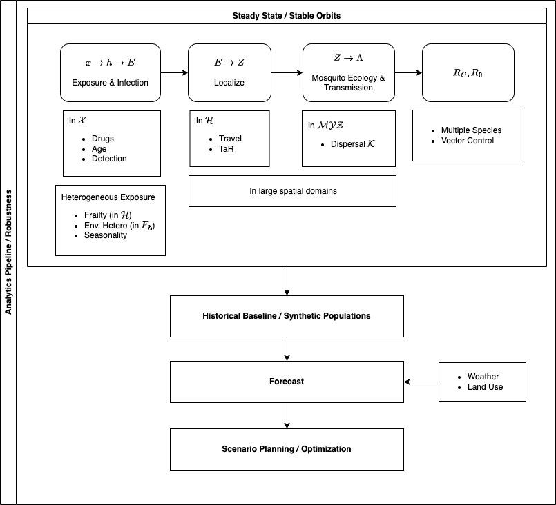

### Data

### Ensembles

**Done**

- Scripted model setup

**Partial**

**Partial**

### Estimation

### Outbreaks

### Counterfactual

### Forecasting

### Optimization

### Policy

**high priority**

- A core algorithm for robust progressive estimation defines a set of Scaling laws for malaria metrics.

## Manuscripts

Also, see the [Google Doc](https://docs.google.com/document/d/1yIMqRp_VPHV7WEIc2B4cw9xe98_zNuBPqMRsm7rSjwk/edit#heading=h.n70ip78pj0sa)

**High Priority**

- **MAFF** - Estimating the Malaria Attributable Fraction of Fever in Cohort Studies through a Before and After Comparison of Impact: Nagongera, Tororo, Uganda 2011-2019. (Dave & Rek)
- **Temporal Dynamics** [Malaria Transmission Dynamics: A Changing Baseline Modified by Control](https://www.overleaf.com/project/5fbc28240b456dace2f15c8d), led by Dave
- [Dispersal in Context](https://www.overleaf.com/project/5f98812fdafbd1000110fe69), led by Hector and Dave. For **PNAS**?
- [Perspectives on Compartmental and State Space Models](https://www.overleaf.com/project/647f02807c8a4f8cecc8a775), led by Doreen
- [A Probabilistic Synthesis of Malaria Epidemiology: Exposure, Infection, Parasite Densities, and Detection](https://www.overleaf.com/project/5ec3f843d3b8f2000187b3e1) John M Henry, David L Smith

## Overview

The **`RAMP Model Library`** contains a large set of interoperable algorithms to simulate and analyze malaria dynamics and control and the dynamics and control of other mosquito-borne pathogens. We set up this up to design a framework for modeling malaria based on some simple design principles and then write supporting software. This code library is where we made all our mistakes, and it still functions as a laboratory for testing ideas. As the primary design phase came to a close, the library that was once the primary code repository has become a classroom and a museum.

The primary code base has moved to CRAN repositories:

- [Micro-MoB](https://cran.r-project.org/package=MicroMoB)
- exDE - watch a slideshow about the Nuts and Bolts

This document is a high-level guide to ongoing development, as we work on new *base models* or as we work on new features. When these projects mature to the point of being functional, the code will migrate to one of the open access software packages, and the version in the library will get deprecated.

Active development to support `exDE` and `MicroMoB` is found in the local directory:

- mob_library

The `RAMP-Model-Library` is now mostly a resource for training see **RAMP**